# Работа на сервере - второй этап внешнего курса

Презентация

Виноградова М. А.

Российский университет дружбы народов, Москва, Россия

16 мая 2025

# Информация

## Докладчик

- Виноградова Мария Андреевна
- Студентка (студ. билет 1132240691)
- группа НПИбд-01-24
- Российский университет дружбы народов
- 1132240691@pfur.ru
- https://github.com/mavinogradova/study_2024-2025_os-intro

# Цель работы

Научится заходить на сервер, запускать различные программы удаленно, а также копировать результаты их выполнения на свой локальный компьютер для дальнейшего анализа.

# Выполнение второго этапа внешнего курса

## Ознакамливаемся с первым вопросом

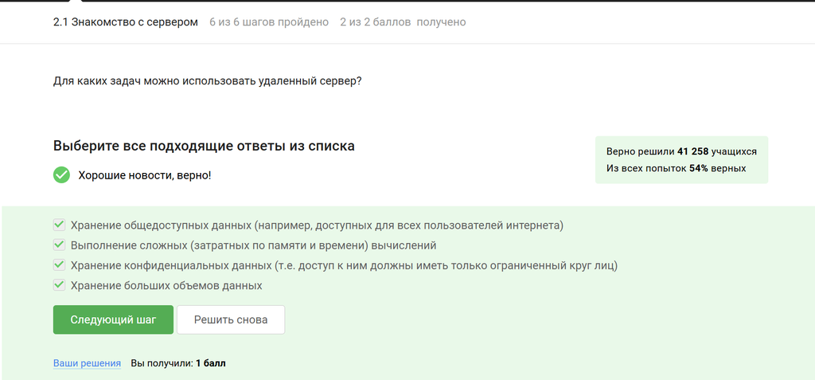

Отвечаем на вопрос

## Почему ответ верен:

- Серверы предназначены для централизованного хранения данных (как открытых, так и защищенных).
- Они обладают мощными ресурсами (CPU, RAM, дисковое пространство), поэтому подходят для ресурсоемких задач.
- Конфиденциальные данные можно защитить с помощью разграничения доступа (например, SSH-ключи, VPN).

## Ознакамливаемся со вторым вопросом

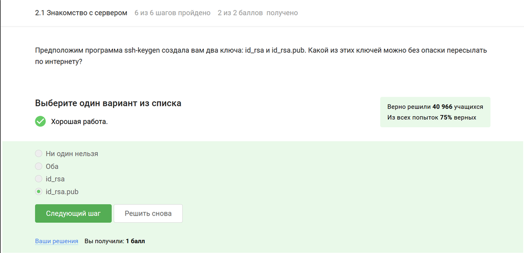

Отвечаем на вопрос

Почему ответ верен:

- id_rsa — приватный ключ, который должен храниться только у владельца. Его утечка компрометирует безопасность.
- id_rsa.pub — публичный ключ, который можно свободно передавать. Он используется для шифрования данных, но без приватного ключа бесполезен.

## Ознакамливаемся с третьим вопросом

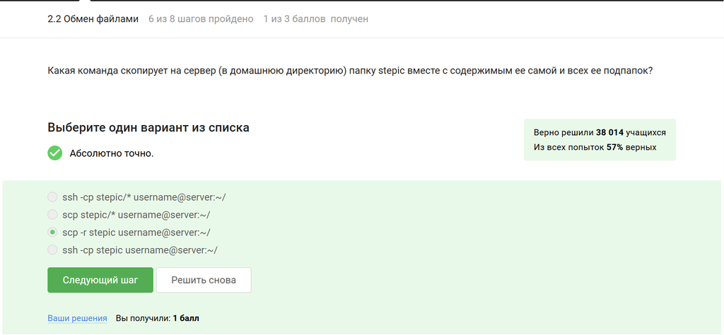

Отвечаем на вопрос

## Почему ответ верен: Смотрим справку по команде команде

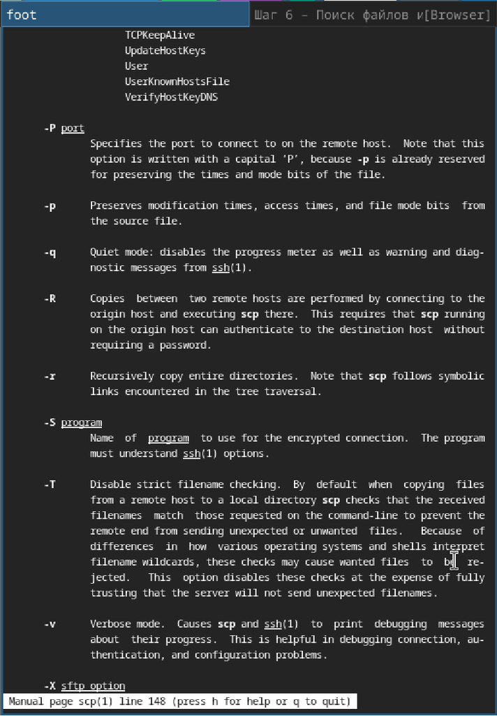

Узнаем ответ на вопрос

## Ознакамливаемся с четвертым вопросом

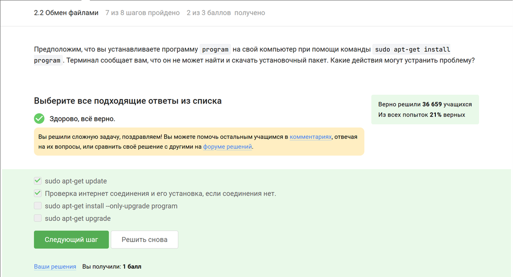

Отвечаем на вопрос

## Почему ответ верен:

Почему не –only-upgrade?

Эта опция обновляет только уже установленные пакеты, но не устанавливает новые.

## Ознакамливаемся с пятым вопросом

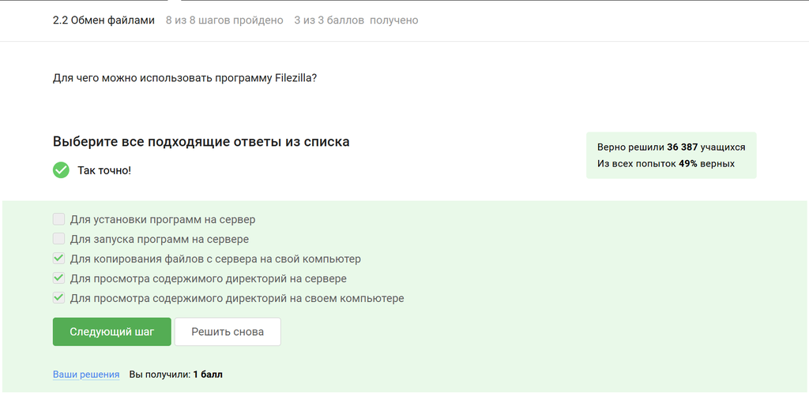

Отвечаем на вопрос

## Почему ответ верен:

FileZilla — это FTP/SFTP-клиент, предназначенный для:

- Передачи файлов между локальной машиной и сервером.
- Навигации по файловой системе (аналогично проводнику).

Не подходит для:

- Установки программ (это делается через терминал, например, apt).
- Запуска программ (требует командной строки или SSH

## Ознакамливаемся с шестым вопросом

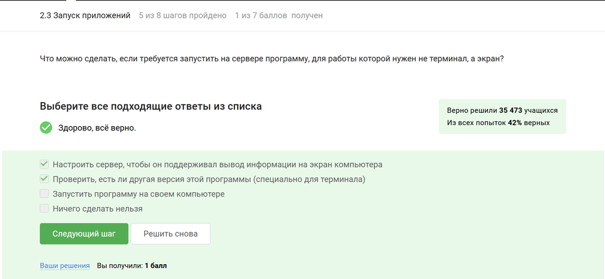

Отвечаем на вопрос

## Почему ответ верен:

- Настроить сервер для вывода на экран (например, через X11-форвардинг).
- Искать терминальную версию программы (например, program –cli).

Почему нельзя просто запустить на своем ПК? Задание предполагает работу именно на сервере, где может не быть графической среды.

## Ознакамливаемся с седьмым вопросом

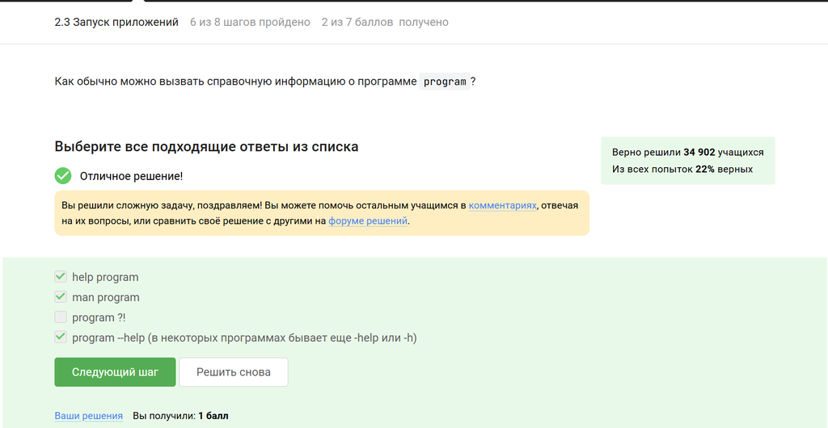

Отвечаем на вопрос

## Почему ответ верен:

Правильные команды:

- man program — стандартное руководство в Linux.
- program –help (или -h) — встроенная справка большинства программ.
- help program — работает для встроенных команд shell (например, help cd).

Почему не program ? Такой синтаксис не поддерживается в Linux.

## Ознакамливаемся с восьмым вопросом

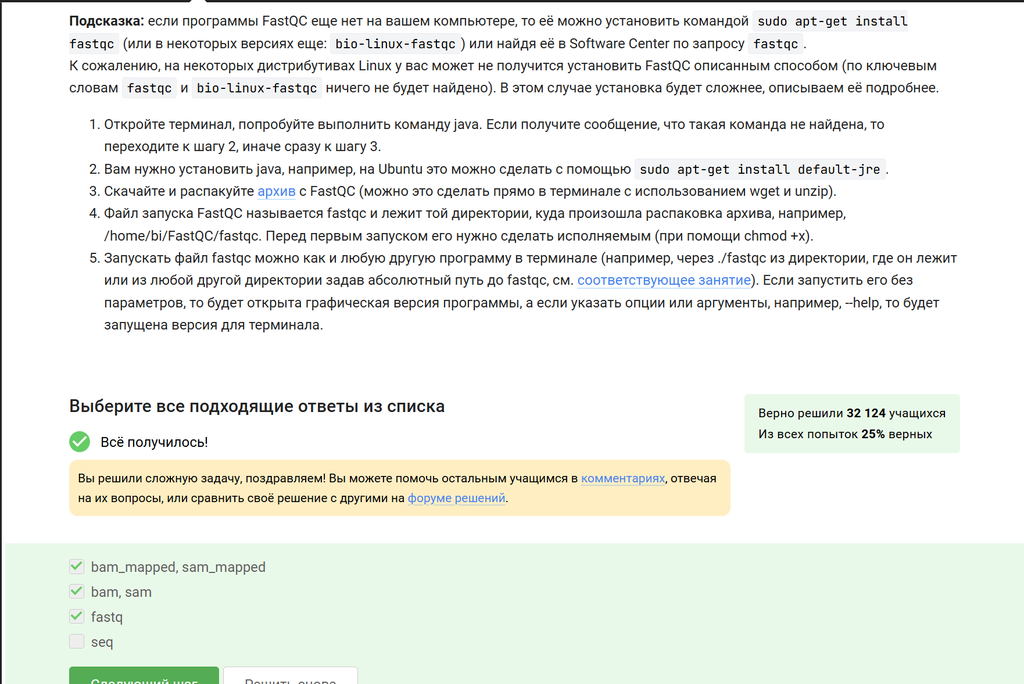

Отвечаем на вопрос

## Почему ответ верен:

FastQC анализирует сырые данные секвенирования (FASTQ) и выровненные данные (BAM/SAM). Версии *_mapped — это подмножества BAM/SAM с отфильтрованными данными.

## Ознакамливаемся с девятым вопросом

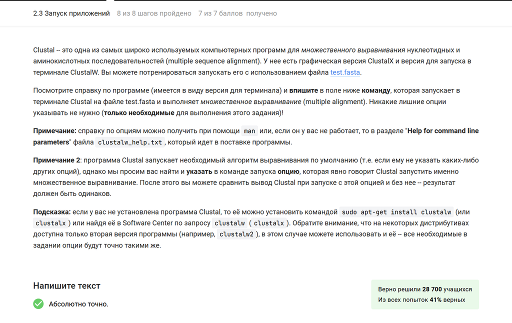

Отвечаем на вопрос

## Почему ответ верен: Смотрим справку по команде и проверяем её выполняя алгоритм выравнивания

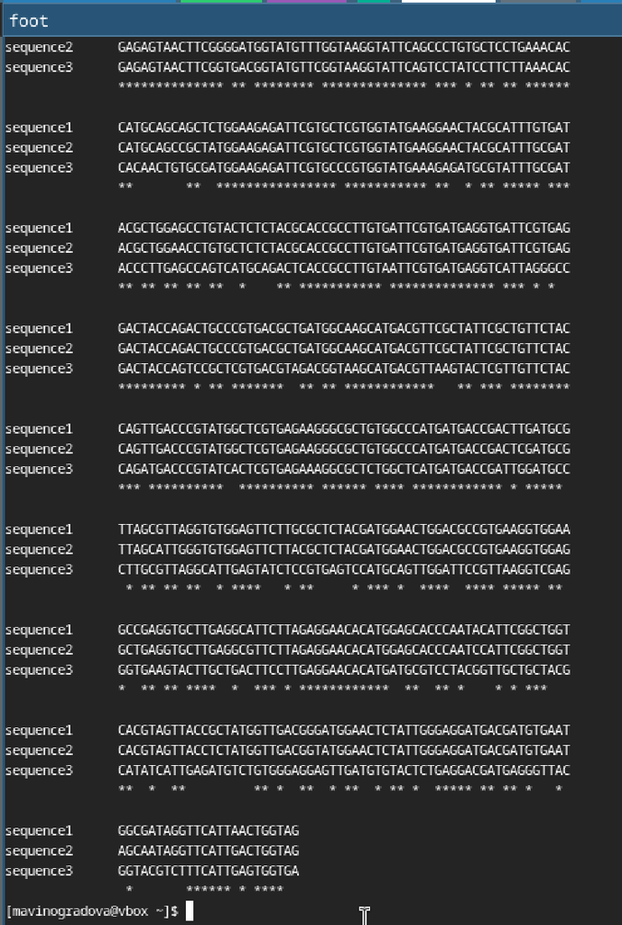

Узнаем ответ на вопрос

## Ознакамливаемся с десятым вопросом

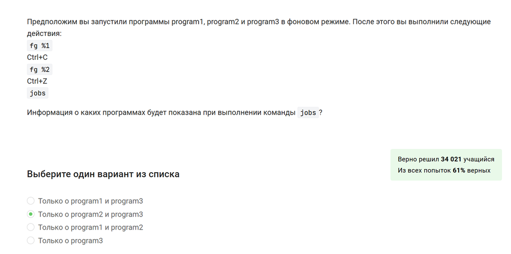

Смотрим текст вопроса

## Выясняем правильный ответ: Запускаем в кансоли три программы в фоновом режиме и после этого выполняем предложенные в задании действия и узнаем правильный ответ

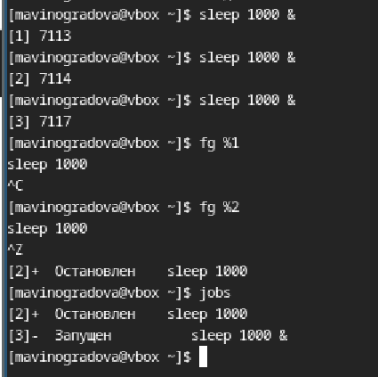

## Отвечаем на вопрос:

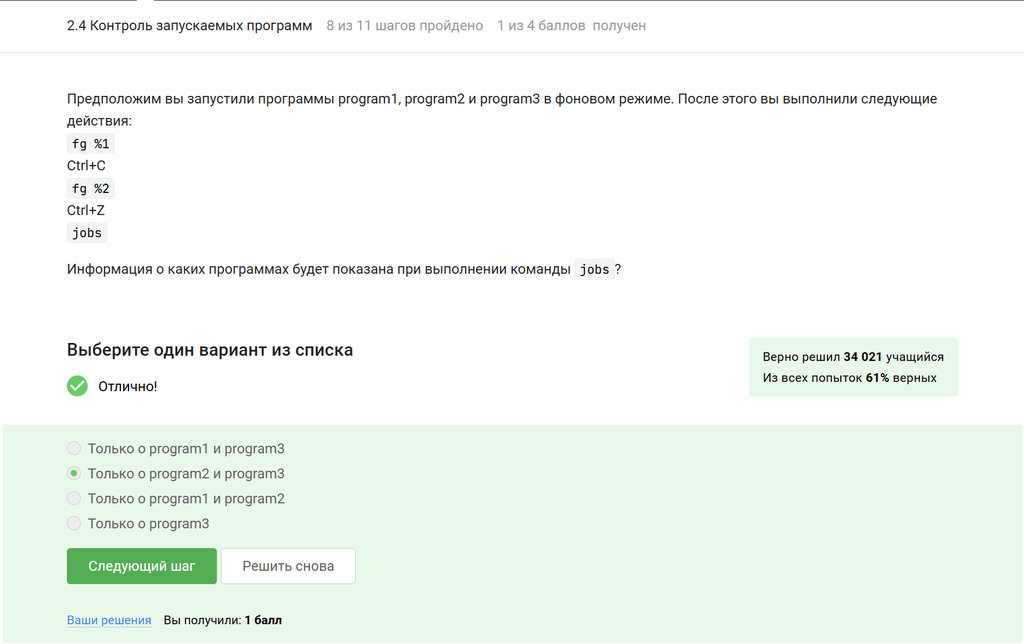

Выбираем правильный ответ

## Ознакамливаемся с одиннадцатым вопросом

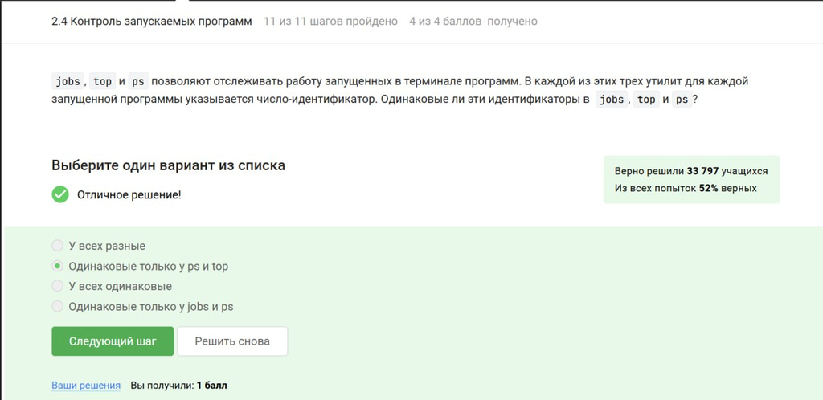

Смотрим текст вопроса

## Выясняем правильный ответ: Запускаем в кансоли одну программу в фоновом режиме, выполняем три команды jobs, top и ps и узнаем одинаковые ли эти идентификаторы

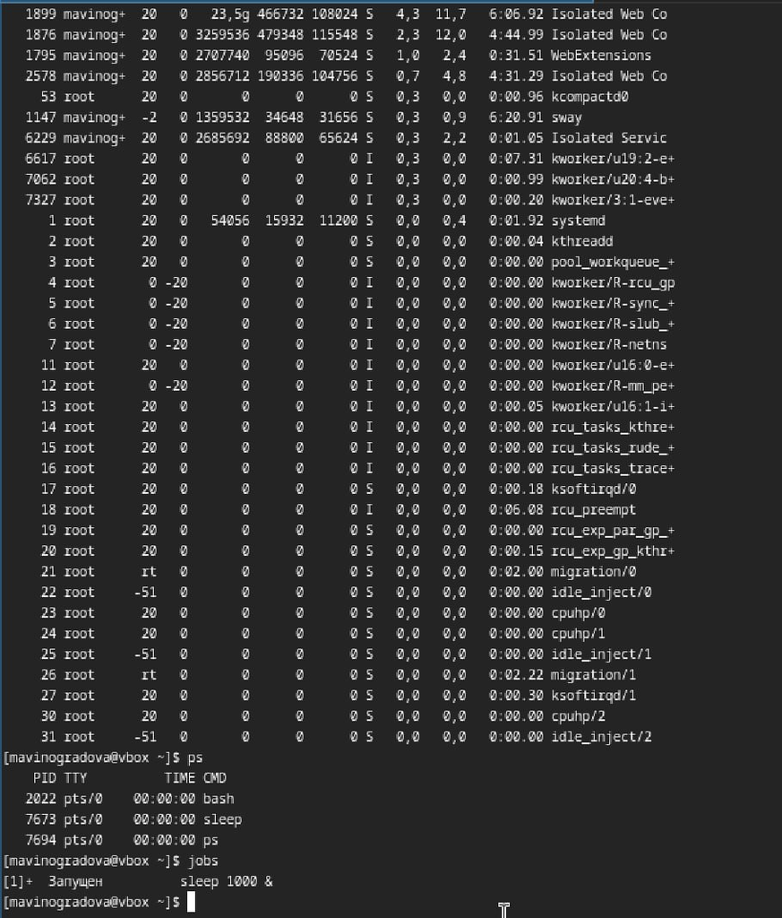

Сравниваем идентефикаторы

## Ознакамливаемся с двенадцатым вопросом

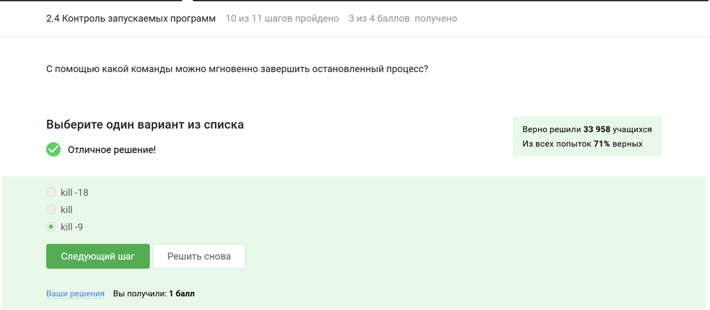

## Почему ответ верен: Запускаем один процесс в фоновом режиме и приостанавливаем его, а затем проверяем все предложенные команды

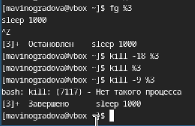

Проверяем команды

## Ознакамливаемся с тринадцатым вопросом

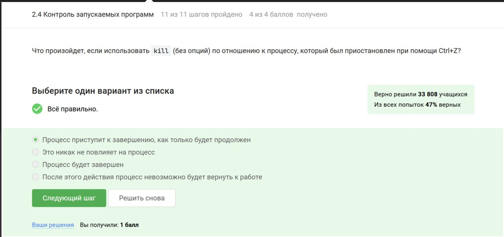

Смотрим текст вопроса

## Почему ответ верен: Проверяем одну предложенную команду

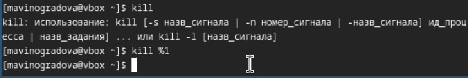

Проверяем команду

## Ознакамливаемся с четырнадцатым вопросом

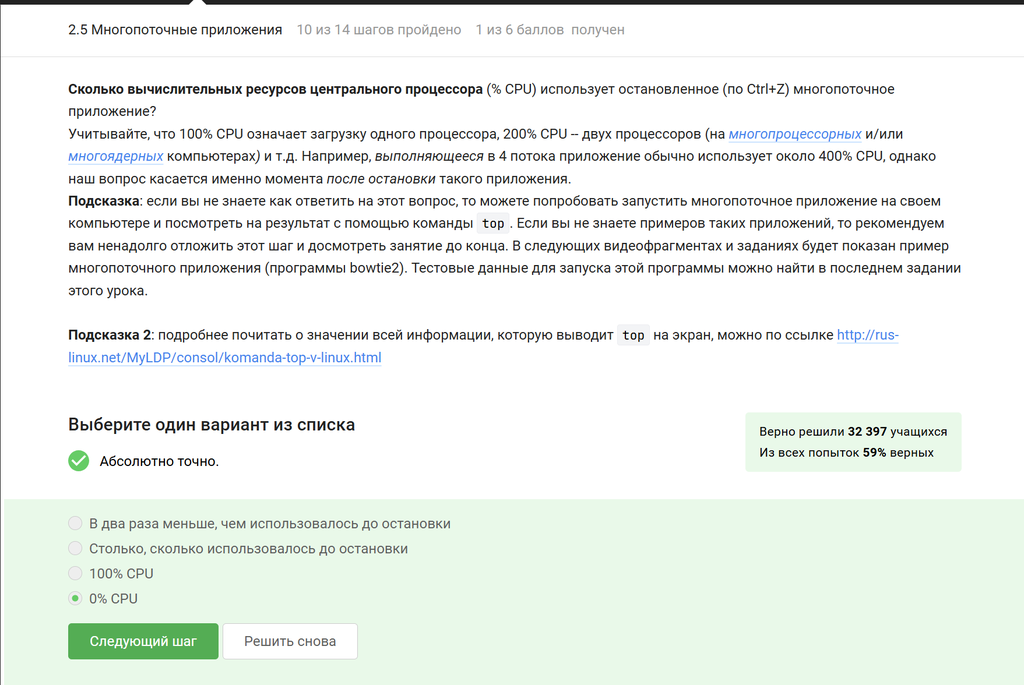

Смотрим текст вопроса

## Почему ответ верен:

При остановке (SIGTSTP) процесс:

- Переходит в состояние T (stopped).
- Не получает процессорного времени (но сохраняет память).

## Ознакамливаемся с пятнадцатым вопросом

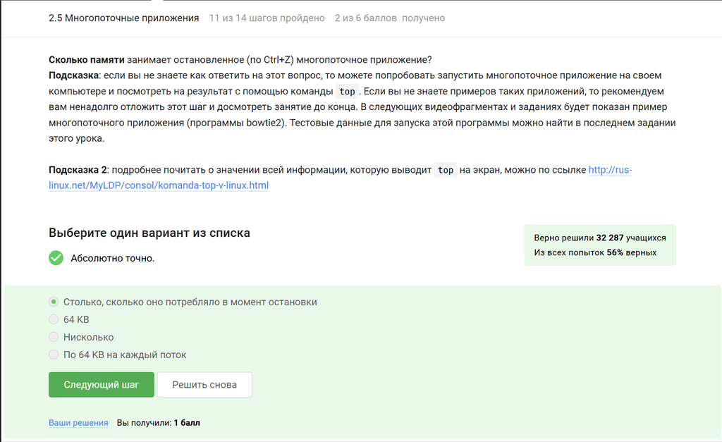

Смотрим текст вопроса

## Почему ответ верен:

Остановленный процесс:

- Остается в RAM (память не освобождается).
- Может быть возобновлен (fg или bg), поэтому система сохраняет его состояние.

64 KB: Это минимальный размер стека потока, но не всего процесса.

## Ознакамливаемся с шестнадцатым вопросом

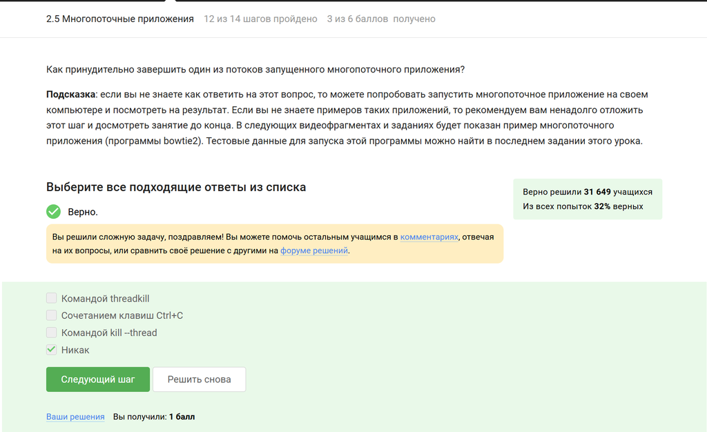

Смотрим текст вопроса

## Почему ответ верен:

- В Linux/UNIX нет стандартного способа завершить отдельный поток процесса.
- Управление потоками (threads) осуществляется внутри самого приложения, а не извне.
- Команды kill или сигналы (например, Ctrl+C) воздействуют на весь процесс, а не на отдельные потоки.

Ошибочные варианты:

- threadkill, kill –thread — таких команд не существует в Linux.
- Ctrl+C — завершает весь процесс, а не поток.

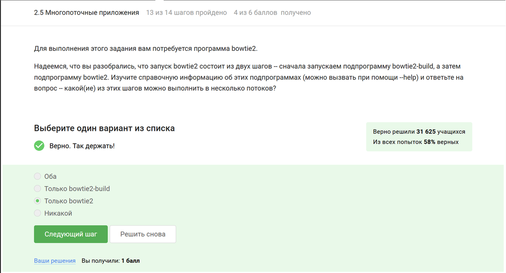

Смотрим текст вопроса

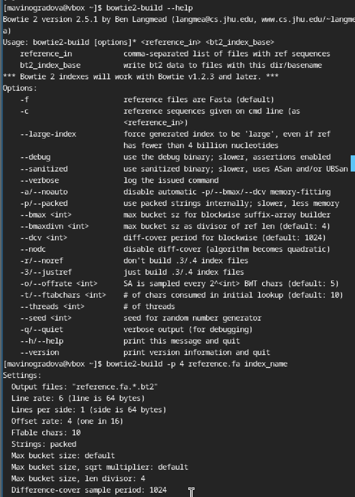

## Ознакамливаемся с семнадцатым вопросом

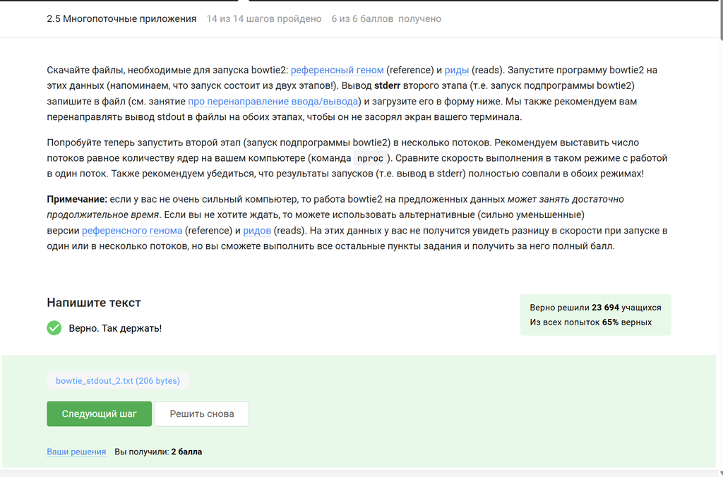

Смотрим текст вопроса

## Почему ответ верен: Скачиваем необходимые файлы, запускаем программу и записываем в файл вывод второго этапа

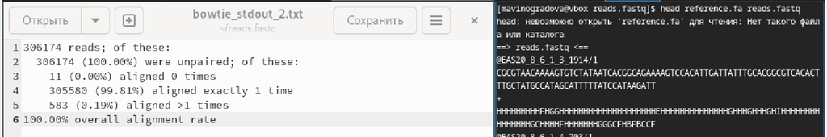

## Ознакамливаемся с восемнадцатым вопросом

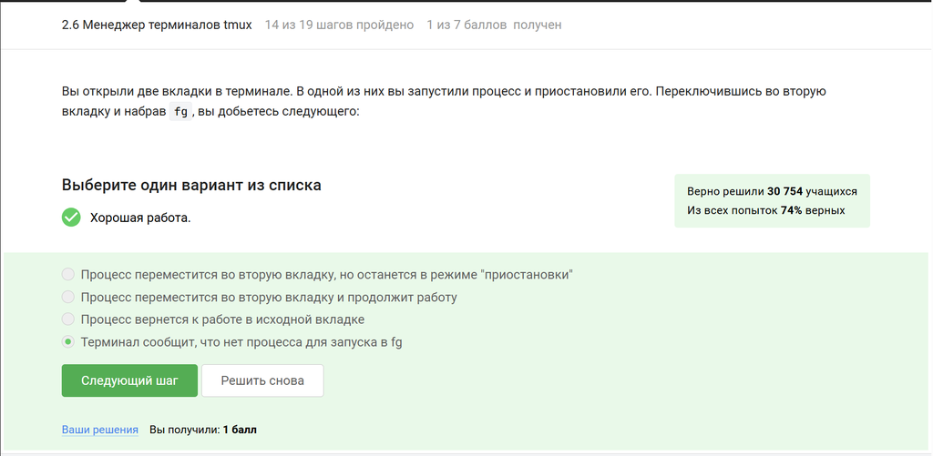

Смотрим текст вопроса